# HW7

Gautham Suresh

2024-03-12

```r
head(Boston)
```

```
##      crim zn indus chas   nox    rm  age    dis rad tax ptratio lstat medv
## 1 0.00632 18  2.31    0 0.538 6.575 65.2 4.0900   1 296    15.3  4.98 24.0
## 2 0.02731  0  7.07    0 0.469 6.421 78.9 4.9671   2 242    17.8  9.14 21.6
## 3 0.02729  0  7.07    0 0.469 7.185 61.1 4.9671   2 242    17.8  4.03 34.7
## 4 0.03237  0  2.18    0 0.458 6.998 45.8 6.0622   3 222    18.7  2.94 33.4
## 5 0.06905  0  2.18    0 0.458 7.147 54.2 6.0622   3 222    18.7  5.33 36.2
## 6 0.02985  0  2.18    0 0.458 6.430 58.7 6.0622   3 222    18.7  5.21 28.7
```

### Problem #1: Multiple Linear Regression

```r
regfit <- regsubsets(medv ~ ., data = Boston, nbest=1, nvmax = 12)

regfit_sum <- summary(regfit)

n = dim(Boston)[1]
p = rowSums(regfit_sum$which)

adjr2 = regfit_sum$adjr2
cp = regfit_sum$cp
rss = regfit_sum$rss
AIC = n*log(rss/n) + 2*(p)
BIC = n*log(rss/n) + (p)*log(n)

subset_table <- data.frame(RSS = rss, Adj_R2 = adjr2, Cp = cp, AIC = AIC, BIC = BIC)

predictors_smallest_AIC <- names(coef(regfit, id = which.min(subset_table$AIC)))
predictors_smallest_BIC <- names(coef(regfit, id = which.min(subset_table$BIC)))
predictors_largest_Adj_R2 <- names(coef(regfit, id = which.max(subset_table$Adj_R2)))
predictors_smallest_Cp <- names(coef(regfit, id = which.min(subset_table$Cp)))

potential_model_predictors <- predictors_smallest_BIC[!predictors_smallest_BIC %in% "(Intercept)"]

potential_formula <- as.formula(paste("medv ~", paste(potential_model_predictors, collapse = " + ")))

temp_model <- lm(potential_formula, data = Boston)
```

1a. **Final model**

```r
best_model_predictors <- predictors_smallest_BIC[!predictors_smallest_BIC %in% c("(Intercept)", "tax")]

formula <- as.formula(paste("medv ~", paste(best_model_predictors, collapse = " + ")))

# This is the final model
final_model <- lm(formula, data = Boston)

coefficients <- coef(final_model)
predictor_names <- names(coefficients)[-1]

final_model_table <- data.frame(Coefficient = coefficients[-1])


print(final_model_table)
```

```
##         Coefficient
## crim     -0.1185421
## zn        0.0365760
## chas      3.1394421
## nox     -21.3756635
## rm        3.8505637
## dis      -1.4507910
## rad       0.1045709
## ptratio  -1.0017531
## lstat    -0.5534612
```

- We found the final model to include the predictors: crim, zn, chas, nox, rm, dis, rad, ptratio, lstat

```r
#Trying the validation set approach

n = dim(Boston)[1]

set.seed(10)
train_index = sample(1:n,n/2,rep=FALSE)

train = Boston[train_index,]
test = Boston[-train_index,]


best_train = regsubsets(medv~.,data=train,nbest=1,nvmax=12)

val_errors = rep(NA,8)
for(i in 1:8){
  test_mat = model.matrix(medv~.,data=test)

  coef_m = coef(best_train,id=i)

  pred = test_mat[,names(coef_m)]%*%coef_m
  val_errors[i] = mean((test$medv-pred)^2)
}

best_model_index <- which.min(val_errors)

best_model_predictors <- names(coef(best_train, id = best_model_index))

best_model_predictors <- best_model_predictors[!best_model_predictors %in% "(Intercept)"]

formula <- as.formula(paste("medv ~", paste(best_model_predictors, collapse = " + ")))

potential_final_model <- lm(formula, data = Boston)
```

1b. **Final model “workflow”**

- We used best subset selection which performs an exhaustive search to identify the optimal combination of predictors. This method was chosen since there are a relatively small number of predictors, meaning it can find the best model in a reasonable amount of time. In this case multiple criteria were tested to determine whether the would produce different models. In most cases, they would produce different results, but in this case, all of the criteria produced the same model.
- The validation set approach was also tested. This produced a different model than the other criteria. The model generated by the above criteria was still chosen, since the validation set approach has the drawback of randomly choosing the training and test data

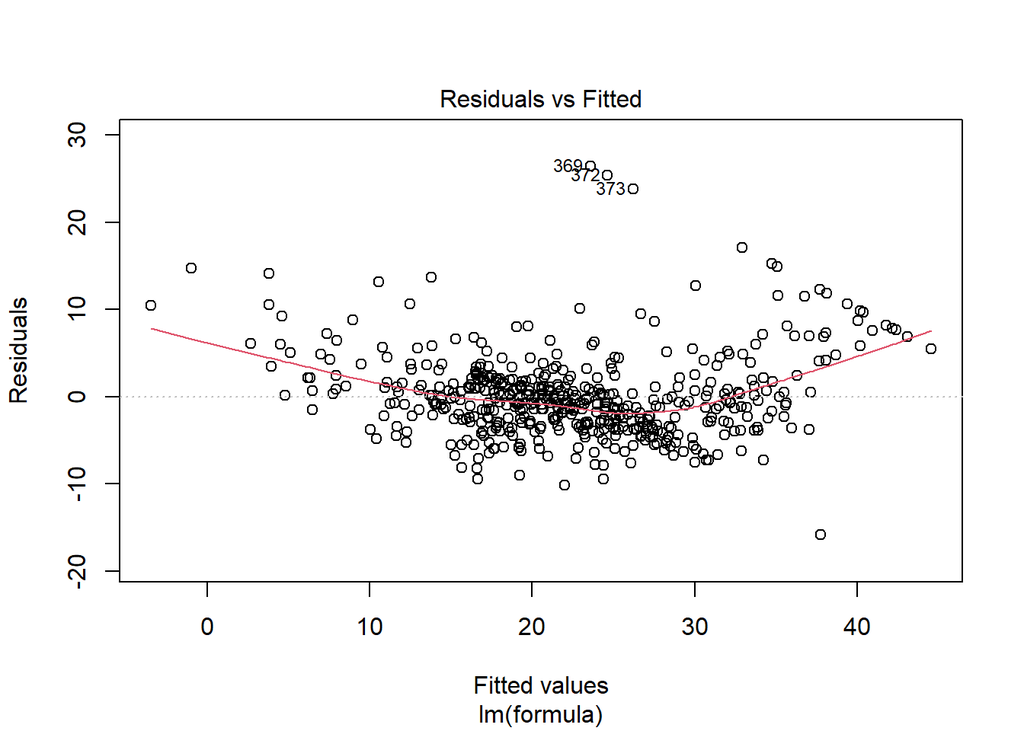

```r
plot(final_model, which = 1)
```

1c. **Assumptions**

1d. **Potential issues**

```r
vif_values <- vif(temp_model)

modified_vif_values <- vif(final_model)
```

- We explore the potential issue of multicollinearity. By calculating the VIF (variance inflation factor) of our model, we can identify potential predictors that are correlated with each other. This method leads us to identify the predictors “rad” and “tax” as being highly correlated with each other as the have VIF values > 4
- To address this issue, we remove the predictor “tax” to reduce multicollinearity
- The VIF values were calculated before and after removing the predictor by storing a temporary model that included “tax”

1e. **Bias and Variance**

```r
#1e.

num_folds <- 10

flds <- createFolds(Boston$medv, k = num_folds, list = TRUE, returnTrain = FALSE)

MSE_values <- numeric(num_folds)

for(i in 1:num_folds) {
  test_index <- flds[[i]]

  test <- Boston[test_index, ]
  train <- Boston[-test_index, ]

  pred_final_model <- predict(final_model, newdata = test)

  MSE_values[i] <- mean((test$medv - pred_final_model)^2)
}

bias <- mean(MSE_values)
variance <- var(MSE_values)
```

- We use cross validation with 10-folds. Based on the average of these results, we will calculate the bias and variance of the model
- Bias = 22.98
- Variance = 77.78